# Project: Investigate a Dataset - Medical Appointment No Shows

- Introduction
- Data Wrangling
- Exploratory Data Analysis
- Conclusions

## Introduction

A person makes a doctor appointment, receives all the instructions and no-show. Whom to blame?

The data talks about the people who booked medical appointments and wether they showed up or not.

The data consists of 14 characteristics of a patient who booked an appointment. Among them, no-show feature is most import one which says wether they showed up for the appointment or no.

### Questions i have made clear to answer about the dataset are:

- Are the Show / No-Show of appointments are related to Gender?
- Which neighbourhood have higher appointments and show/No-show in them
- how good messaging appointment people helped in show up for appointment data?

```python
# required libraries
import numpy as np
import pandas as pd
import matplotlib.pyplot as plt
import seaborn as sns

sns.set()
%matplotlib inline
```

## Data Wrangling

### General Properties

```python
# Load your data and print out a few lines. Perform operations to inspect data
#   types and look for instances of missing or possibly errant data.
df = pd.read_csv('noshowappointments-kagglev2-may-2016.csv')
df.head()
```

|  | PatientId | AppointmentID | Gender | ScheduledDay | AppointmentDay | Age | Neighbourhood | Scholarship | Hipertension | Diabetes | Alcoholism | Handcap | SMS_received | No-show |
| --- | --- | --- | --- | --- | --- | --- | --- | --- | --- | --- | --- | --- | --- | --- |
| 0 | 2.987250e+13 | 5642903 | F | 2016-04-29T18:38:08Z | 2016-04-29T00:00:00Z | 62 | JARDIM DA PENHA | 0 | 1 | 0 | 0 | 0 | 0 | No |
| 1 | 5.589978e+14 | 5642503 | M | 2016-04-29T16:08:27Z | 2016-04-29T00:00:00Z | 56 | JARDIM DA PENHA | 0 | 0 | 0 | 0 | 0 | 0 | No |
| 2 | 4.262962e+12 | 5642549 | F | 2016-04-29T16:19:04Z | 2016-04-29T00:00:00Z | 62 | MATA DA PRAIA | 0 | 0 | 0 | 0 | 0 | 0 | No |
| 3 | 8.679512e+11 | 5642828 | F | 2016-04-29T17:29:31Z | 2016-04-29T00:00:00Z | 8 | PONTAL DE CAMBURI | 0 | 0 | 0 | 0 | 0 | 0 | No |
| 4 | 8.841186e+12 | 5642494 | F | 2016-04-29T16:07:23Z | 2016-04-29T00:00:00Z | 56 | JARDIM DA PENHA | 0 | 1 | 1 | 0 | 0 | 0 | No |

```python
# Get to know available features
df.columns
```

```
Index(['PatientId', 'AppointmentID', 'Gender', 'ScheduledDay',
       'AppointmentDay', 'Age', 'Neighbourhood', 'Scholarship', 'Hipertension',
       'Diabetes', 'Alcoholism', 'Handcap', 'SMS_received', 'No-show'],
      dtype='object')
```

```python
# rename columns
df.rename(columns = {"Hipertension" : "Hypertension", "Handcap" : "Handicap", "No-show" : "No_show"}, inplace=True)
```

```python
df.describe()
```

|  | PatientId | AppointmentID | Age | Scholarship | Hypertension | Diabetes | Alcoholism | Handicap | SMS_received |
| --- | --- | --- | --- | --- | --- | --- | --- | --- | --- |
| count | 1.105270e+05 | 1.105270e+05 | 110527.000000 | 110527.000000 | 110527.000000 | 110527.000000 | 110527.000000 | 110527.000000 | 110527.000000 |
| mean | 1.474963e+14 | 5.675305e+06 | 37.088874 | 0.098266 | 0.197246 | 0.071865 | 0.030400 | 0.022248 | 0.321026 |
| std | 2.560949e+14 | 7.129575e+04 | 23.110205 | 0.297675 | 0.397921 | 0.258265 | 0.171686 | 0.161543 | 0.466873 |
| min | 3.921784e+04 | 5.030230e+06 | -1.000000 | 0.000000 | 0.000000 | 0.000000 | 0.000000 | 0.000000 | 0.000000 |
| 25% | 4.172614e+12 | 5.640286e+06 | 18.000000 | 0.000000 | 0.000000 | 0.000000 | 0.000000 | 0.000000 | 0.000000 |
| 50% | 3.173184e+13 | 5.680573e+06 | 37.000000 | 0.000000 | 0.000000 | 0.000000 | 0.000000 | 0.000000 | 0.000000 |
| 75% | 9.439172e+13 | 5.725524e+06 | 55.000000 | 0.000000 | 0.000000 | 0.000000 | 0.000000 | 0.000000 | 1.000000 |
| max | 9.999816e+14 | 5.790484e+06 | 115.000000 | 1.000000 | 1.000000 | 1.000000 | 1.000000 | 4.000000 | 1.000000 |

```python
# data types for each column
df.dtypes
```

```
PatientId         float64
AppointmentID       int64
Gender             object
ScheduledDay       object
AppointmentDay     object
Age                 int64
Neighbourhood      object
Scholarship         int64
Hypertension        int64
Diabetes            int64
Alcoholism          int64
Handicap            int64
SMS_received        int64
No_show            object
dtype: object
```

Types of datatypes in dataset are Categorical and numerical.

•Categorical features:'Gender', 'Neighbourhood', 'Scholarship', 'Hypertension', 'Diabetes', 'Alcoholism', 'Handicap', 'SMS_received', 'No_show'

•Numerical features: Age, AppointmentID, ScheduledDay and AppointmentDay (Date-time format)

## Data manipulation

```python
# Change to datetime format

df['ScheduledDay'] = df['ScheduledDay'].apply(np.datetime64)
df['Scheduled_Time'] = [d.time() for d in df['ScheduledDay']]
df['Scheduled_Day'] = df['ScheduledDay'].dt.day
df['Scheduled_Weekday'] = df['ScheduledDay'].dt.dayofweek
df['Scheduled_Month'] = df['ScheduledDay'].dt.month


df['AppointmentDay'] = df['AppointmentDay'].apply(np.datetime64)
df['Appointment_Day'] = df['AppointmentDay'].dt.day
df['Appointment_Week'] = df['AppointmentDay'].dt.dayofweek
df['Appointment_Month'] = df['AppointmentDay'].dt.month
df.drop(['AppointmentDay', 'ScheduledDay'], axis=1, inplace=True)
```

```python
## replace categorical label in Gender and No_Show
# Gender M=0, F=1
# No_show No=0, Yes=1
change_cols = {"Gender" : { "M" : 0, "F" : 1 },
               "No_show": { "No" : 0, "Yes" : 1 },
               }
df.replace(change_cols, inplace=True)
```

```python
df.head(10)
```

|  | PatientId | AppointmentID | Gender | Age | Neighbourhood | Scholarship | Hypertension | Diabetes | Alcoholism | Handicap | SMS_received | No_show | Scheduled_Time | Scheduled_Day | Scheduled_Weekday | Scheduled_Month | Appointment_Day | Appointment_Week | Appointment_Month |
| --- | --- | --- | --- | --- | --- | --- | --- | --- | --- | --- | --- | --- | --- | --- | --- | --- | --- | --- | --- |
| 0 | 2.987250e+13 | 5642903 | 1 | 62 | JARDIM DA PENHA | 0 | 1 | 0 | 0 | 0 | 0 | 0 | 18:38:08 | 29 | 4 | 4 | 29 | 4 | 4 |
| 1 | 5.589978e+14 | 5642503 | 0 | 56 | JARDIM DA PENHA | 0 | 0 | 0 | 0 | 0 | 0 | 0 | 16:08:27 | 29 | 4 | 4 | 29 | 4 | 4 |
| 2 | 4.262962e+12 | 5642549 | 1 | 62 | MATA DA PRAIA | 0 | 0 | 0 | 0 | 0 | 0 | 0 | 16:19:04 | 29 | 4 | 4 | 29 | 4 | 4 |
| 3 | 8.679512e+11 | 5642828 | 1 | 8 | PONTAL DE CAMBURI | 0 | 0 | 0 | 0 | 0 | 0 | 0 | 17:29:31 | 29 | 4 | 4 | 29 | 4 | 4 |
| 4 | 8.841186e+12 | 5642494 | 1 | 56 | JARDIM DA PENHA | 0 | 1 | 1 | 0 | 0 | 0 | 0 | 16:07:23 | 29 | 4 | 4 | 29 | 4 | 4 |
| 5 | 9.598513e+13 | 5626772 | 1 | 76 | REPÚBLICA | 0 | 1 | 0 | 0 | 0 | 0 | 0 | 08:36:51 | 27 | 2 | 4 | 29 | 4 | 4 |
| 6 | 7.336882e+14 | 5630279 | 1 | 23 | GOIABEIRAS | 0 | 0 | 0 | 0 | 0 | 0 | 1 | 15:05:12 | 27 | 2 | 4 | 29 | 4 | 4 |
| 7 | 3.449833e+12 | 5630575 | 1 | 39 | GOIABEIRAS | 0 | 0 | 0 | 0 | 0 | 0 | 1 | 15:39:58 | 27 | 2 | 4 | 29 | 4 | 4 |
| 8 | 5.639473e+13 | 5638447 | 1 | 21 | ANDORINHAS | 0 | 0 | 0 | 0 | 0 | 0 | 0 | 08:02:16 | 29 | 4 | 4 | 29 | 4 | 4 |
| 9 | 7.812456e+13 | 5629123 | 1 | 19 | CONQUISTA | 0 | 0 | 0 | 0 | 0 | 0 | 0 | 12:48:25 | 27 | 2 | 4 | 29 | 4 | 4 |

```python
# any duplicates
print("No. of duplicate rows:", sum(df.duplicated()))
```

```
No. of duplicate rows: 0
```

```python
# check for null values
df.isnull().any()
```

```
PatientId            False
AppointmentID        False
Gender               False
Age                  False
Neighbourhood        False
Scholarship          False
Hypertension         False
Diabetes             False
Alcoholism           False
Handicap             False
SMS_received         False
No_show              False
Scheduled_Time       False
Scheduled_Day        False
Scheduled_Weekday    False
Scheduled_Month      False
Appointment_Day      False
Appointment_Week     False
Appointment_Month    False
dtype: bool
```

There are no null values in raw data

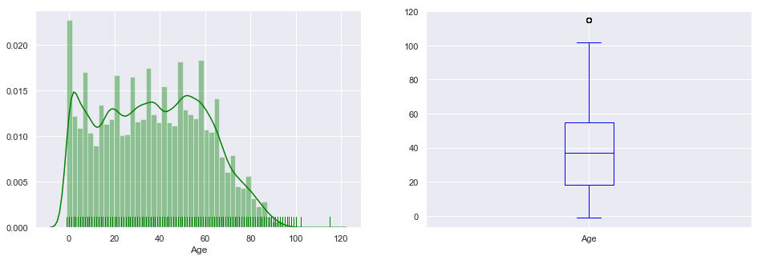

```python
# Age
plt.subplot(121)
sns.distplot(df['Age'],  rug=True, color = 'green')

plt.subplot(122)
df['Age'].plot.box(figsize=(16,5), color = "blue");
```

The age cannot be less than zero and in box plot there is a outlier values after 100

```python
# exclude data
drop_rows = df[(df.Age < 0) | (df.Age > 100)].index
df.drop(drop_rows, inplace=True)
```

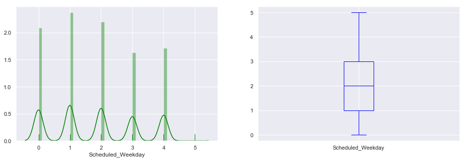

```python
# Weekday scheduled
plt.subplot(121)
sns.distplot(df['Scheduled_Weekday'],  rug=True, color = 'green')

plt.subplot(122)
df['Scheduled_Weekday'].plot.box(figsize=(16,5), color = "blue");
```

for weekday 0 - Monday, 5 -saturday It can be infer that from weekdays that most of the appointmnets are scheduled for Tuesday, followed by wednesday and least on Saturday

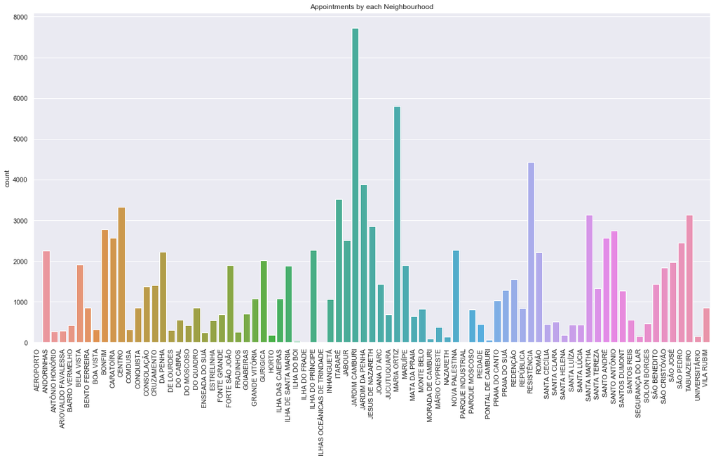

```python
# Neighborhood
ax = plt.figure(figsize=(20,10))
ax = sns.countplot(x=np.sort(df.Neighbourhood))
ax.set_title("Appointments by each Neighbourhood")
plt.xticks(rotation=90);
```

From area 'Jardim Camburi' has more appointments

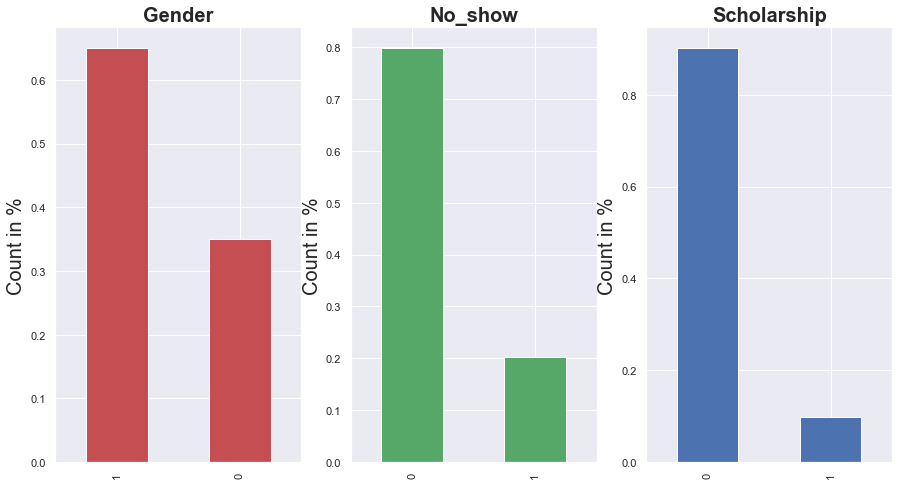

```python
plt.figure(figsize = (15,8))
cols = ['Gender', 'No_show', 'Scholarship']

colour = ['r', 'g', 'b']
i = 0
for col in cols:
    plt.subplot(int(str(13)+str((cols.index(col)+1))))
    df[col].value_counts(normalize=True).plot.bar(color = colour[i])
    plt.title(col, fontweight="bold", fontsize = 20)
    plt.ylabel('Count in %', fontsize = 20)
    i +=1
```

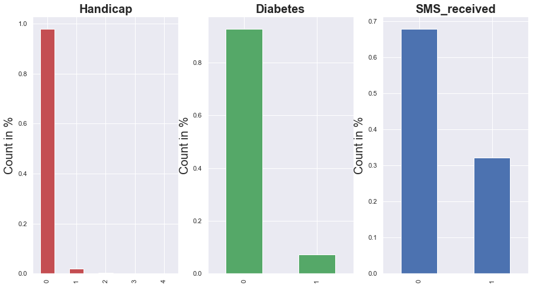

```python
plt.figure(figsize = (15,8))
cols = ['Handicap', 'Diabetes', 'SMS_received']

colour = ['r', 'g', 'b']
i = 0
for col in cols:
    plt.subplot(int(str(13)+str((cols.index(col)+1))))
    df[col].value_counts(normalize=True).plot.bar(color = colour[i])
    plt.title(col, fontweight="bold", fontsize = 20)
    plt.ylabel('Count in %', fontsize = 20)
    i +=1
```

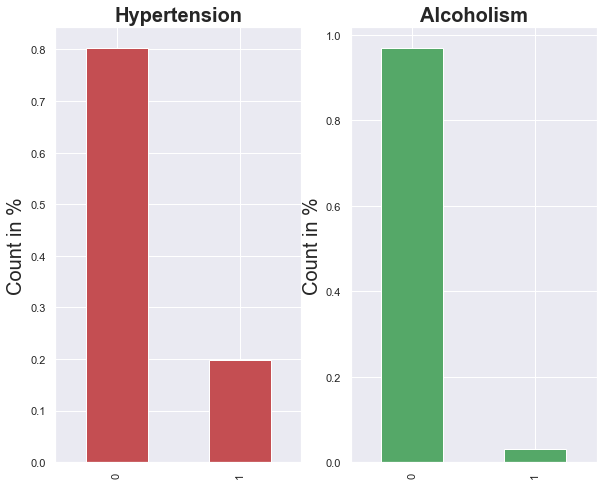

```python
plt.figure(figsize = (15,8))
cols = ['Hypertension', 'Alcoholism']

colour = ['r', 'g', 'b']
i = 0
for col in cols:
    plt.subplot(int(str(13)+str((cols.index(col)+1))))
    df[col].value_counts(normalize=True).plot.bar(color = colour[i])
    plt.title(col, fontweight="bold", fontsize = 20)
    plt.ylabel('Count in %', fontsize = 20)
    i +=1
```

#### Multi-variate analysis

```python
# relation
df_new = df.groupby('No_show')['Scholarship', 'Hypertension',
                       'Diabetes', 'Alcoholism', 'Handicap', 'SMS_received'].sum()
```

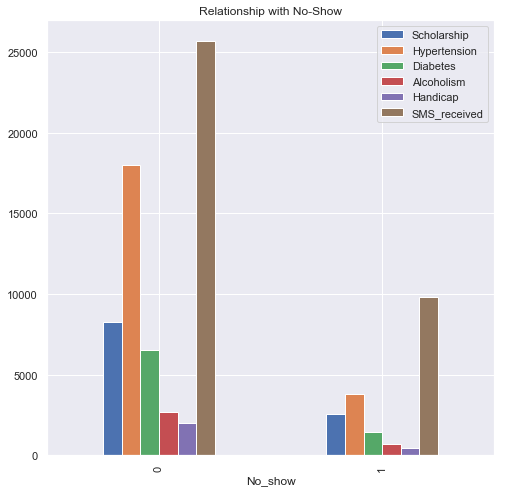

```python
df_new.plot(kind='bar',figsize=(8,8),\
            title='Relationship with No-Show');
```

## Exploratory Data Analysis

### Show / No-Show of appointments based on gender?

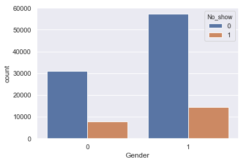

```python
sns.countplot(x=df.Gender, hue=df.No_show)
```

seems to be no much difference in Genderwise. Even in No-show and show up appointments are almost same proportion between genders

### Which neighbourhood have higher appointments?

[figure not shown]

```python
plt.figure(figsize=(20, 10))
plt.xticks(rotation=90)
sns.countplot(x=df.Neighbourhood, hue=df.No_show order=df.Neighbourhood.value_counts().index);
```

### Conversion rate of SMS to attend appointments?

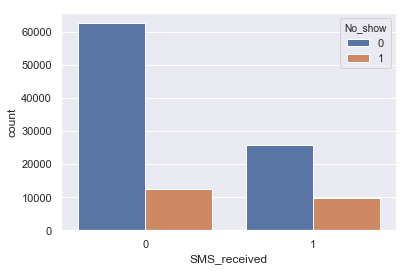

```python
sns.countplot(x=df.SMS_received, hue=df.No_show)
```

it is strange, that the people who received SMS have less conversion rate to attend the appointment than who didnot recieved

## Limitations

- If the reason for medical appointment is given we could be clear and use diseases to get more understanding
- Might be data is highly colected from a single neighborhood where we cannot differentiate if neighborhood played anyrole in appointments no-show.

## Conclusions

- Genderwise appointments are more with female, where female takes care health more than male.
- Highest appointments are from Jardim Camburi and no follow-up trend wether to get info from neighborhood base for no-show up.
- SMS_recived should be more elaborated such ha show many messages are sent.
- Majority of the appointments booked on the weeekdays (Tuesday Wednesday) when compared to weekends (Saturday). Might be middle of weekdays are the best for appointments to book and showup